# Statistical Inference Project Tooth Growth

Thomas Sacchetti

August 17, 2015

# Overview

This project will examine utilize technique from the Johns Hopkins Statistical Inference class, to gain insights into the Tooth Growth dataset. We will use hypothesis testing and confidence intervals in order to develop a strong understanding of the dataset as a whole. We will answer two questions first does the supplement type effect the results of Tooth Growth. Second, we will check to see if the growth increases as dosage increases.

# Load Data

```r
library(ggplot2)
data(ToothGrowth)
summary(ToothGrowth)
```

```
##       len        supp         dose
##  Min.   : 4.20   OJ:30   Min.   :0.500
##  1st Qu.:13.07   VC:30   1st Qu.:0.500
##  Median :19.25           Median :1.000
##  Mean   :18.81           Mean   :1.167
##  3rd Qu.:25.27           3rd Qu.:2.000
##  Max.   :33.90           Max.   :2.000
```

From the summary we can say that we know the dosage is between .5 and 2 and the length is between 4 and 34.

```r
table(is.na(ToothGrowth))
```

```
##
## FALSE
##   180
```

Additionally we know that there are no NA values in the data set from the above table. Now we will look at a quick discovery plot to get a sense for distribution.

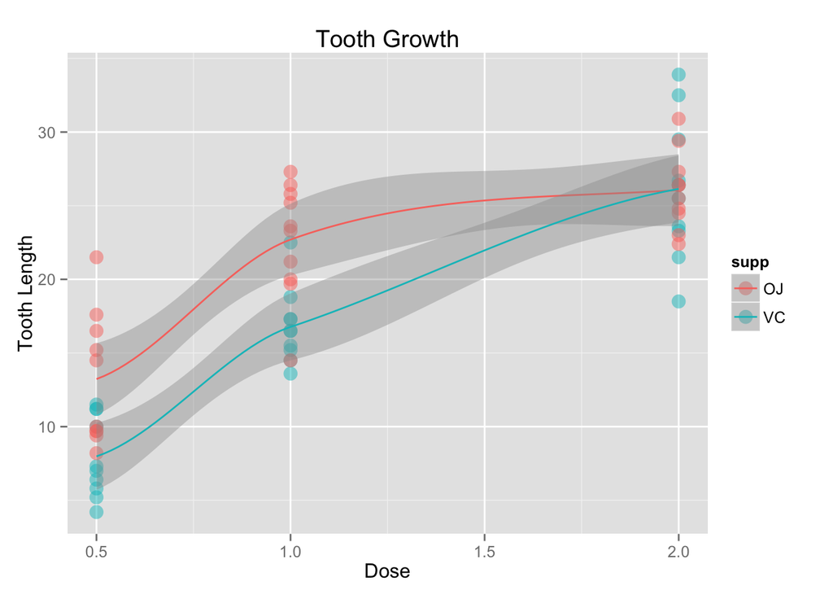

```r
g <- ggplot(ToothGrowth, aes(dose, len))
g + geom_point(aes(color = supp), size = 4, alpha = 1/2) + labs(title = "Tooth Growth") + labs(x ="Dose", y="Tooth Length") + geom_smooth(aes(color = supp))
```

# Question 1

We will begin by answering the first question, is the a different effect on OJ or VC growth. In order to do this we will compare mean, standard deviation and varaition accross each of the sets. In this case we are testing the null hypothesis HO, Supplement type does not have an effect on Length H1, Supplement length is effected by the choice of supplement.

```r
OJ.dat = ToothGrowth[ToothGrowth$supp == "OJ",]
VC.dat = ToothGrowth[ToothGrowth$supp == "VC",]

mean.OJ = mean(OJ.dat[,"len"])
sd.OJ = sd(OJ.dat[,"len"])
length.OJ = length(OJ.dat[,1])

mean.VC = mean(VC.dat[,"len"])
sd.VC = sd(VC.dat[,"len"])
length.VC = length(VC.dat[,1])

OJ.stats = c(mean.OJ,sd.OJ,length.OJ)
VC.stats = c(mean.VC,sd.VC,length.VC)
Total = as.data.frame(OJ.stats)
Total = cbind(Total,VC.stats)
row.names(Total) = c("Mean", "Standard Deviation", "Length")
as.matrix(Total)
```

```
##                     OJ.stats  VC.stats
## Mean               20.663333 16.963333
## Standard Deviation  6.605561  8.266029
## Length             30.000000 30.000000
```

Now that we have a general idea from the above table of the general layout of the data we can proceed with a T test.

```r
t.test(OJ.dat$len, VC.dat$len, paired = FALSE, var.equal = TRUE)
```

```
##
##  Two Sample t-test
##
## data:  OJ.dat$len and VC.dat$len
## t = 1.9153, df = 58, p-value = 0.06039
## alternative hypothesis: true difference in means is not equal to 0
## 95 percent confidence interval:
##  -0.1670064  7.5670064
## sample estimates:
## mean of x mean of y
##  20.66333  16.96333
```

From the results of the T.test we fail to reject the null hypothesis for the T.test.

# Question 2

```r
dat.5 = ToothGrowth[ToothGrowth$dose == 0.5,]
dat.1 = ToothGrowth[ToothGrowth$dose == 1.00,]
dat.2 = ToothGrowth[ToothGrowth$dose == 2.00,]


mean.5 = mean(dat.5[,"len"])
sd.5 = sd(dat.5[,"len"])
length.5 = length(dat.5[,1])

mean.1 = mean(VC.dat[,"len"])
sd.1 = sd(dat.1[,"len"])
length.1 = length(dat.1[,1])

mean.2 = mean(VC.dat[,"len"])
sd.2 = sd(dat.1[,"len"])
length.2 = length(dat.2[,1])

stats.5 = c(mean.5,sd.5,length.5)
stats.2 = c(mean.2,sd.2,length.2)
stats.1 = c(mean.1,sd.1,length.1)

Total = as.data.frame(stats.5)
Total = cbind(Total,stats.1,stats.2)
row.names(Total) = c("Mean", "Standard Deviation", "Length")
as.matrix(Total)
```

```
##                      stats.5   stats.1   stats.2
## Mean               10.605000 16.963333 16.963333
## Standard Deviation  4.499763  4.415436  4.415436
## Length             20.000000 20.000000 20.000000
```

Now we must T test in the incremental intervals in order to show that as dosage increases the growth increases. The first test tests the dosage increase from .5 to 1.00.

```r
t.test(dat.1$len, dat.5$len, paired = FALSE, var.equal = TRUE,alternative = "greater")
```

```
##
##  Two Sample t-test
##
## data:  dat.1$len and dat.5$len
## t = 6.4766, df = 38, p-value = 6.331e-08
## alternative hypothesis: true difference in means is greater than 0
## 95 percent confidence interval:
##  6.753344      Inf
## sample estimates:
## mean of x mean of y
##    19.735    10.605
```

Given the low p value we are able to reject the null hypothesis. Now we will t.test the dosage from 1.00 to 2.00.

```r
t.test(dat.2$len, dat.1$len, paired = FALSE, var.equal = TRUE,alternative = "greater")
```

```
##
##  Two Sample t-test
##
## data:  dat.2$len and dat.1$len
## t = 4.9005, df = 38, p-value = 9.054e-06
## alternative hypothesis: true difference in means is greater than 0
## 95 percent confidence interval:
##  4.175196      Inf
## sample estimates:
## mean of x mean of y
##    26.100    19.735
```

We are again able to reject the null hypothesis because the p value is less than .05. Lastly we will check the growth from .5 to 2.00.

```r
t.test(dat.2$len, dat.5$len, paired = FALSE, var.equal = TRUE,alternative = "greater")
```

```
##
##  Two Sample t-test
##
## data:  dat.2$len and dat.5$len
## t = 11.799, df = 38, p-value = 1.419e-14
## alternative hypothesis: true difference in means is greater than 0
## 95 percent confidence interval:
##  13.28093      Inf
## sample estimates:
## mean of x mean of y
##    26.100    10.605
```

Again with our low p value we are able to reject our null hypothesis.

# Conclusion

In response the question one we are not able to reject our null hypothesis from out t test, to claim that the supplement type does have an effect on growth rate. For the second question we were once again able to confirm out alternate hypothesis from the three different t.tests that were performed.